# Análisis Estadístico del Rendimiento de Funciones C: Arquitecturas y Compiladores con Diseño de Bloques

Análisis Experimental - CI0131

2025-07-02

# 1. Introducción y Contextualización

Este documento presenta el análisis estadístico completo del experimento diseñado para evaluar el efecto de la arquitectura de CPU y el compilador en el rendimiento de funciones escritas en lenguaje C. El estudio implementa un **diseño factorial 2×2 con bloques**, donde los bloques están definidos por el nivel de uso de memoria de las funciones ejecutadas.

## 1.1 Problema de Investigación

En el dominio del desarrollo de software de alto rendimiento, la elección de la arquitectura de procesamiento y el compilador ejerce una influencia sustancial en el tiempo de ejecución y el uso de recursos. Este experimento busca cuantificar dichos efectos mediante metodologías rigurosas de diseño experimental.

## 1.2 Objetivos del Análisis

- Evaluar los efectos principales de la arquitectura (Intel vs Ryzen) y el compilador (GCC vs Clang) en el tiempo de ejecución
- Detectar posibles interacciones entre arquitectura y compilador
- Implementar blocking basado en el uso de memoria para controlar la variabilidad
- Validar supuestos estadísticos y realizar análisis apropiados
- Proporcionar conclusiones basadas en evidencia estadística

# 2. Carga y Preparación de Datos

```
## CONFIGURACIÓN COMPLETADA:
## - Todos los paquetes necesarios están instalados y cargados
## - Tema de gráficos configurado
## - Análisis listo para ejecutar
```

```
## 'data.frame':    5980 obs. of  6 variables:
##  $ filename    : Factor w/ 300 levels "1.c","10.c","100.c",..: 1 2 3 4 5 6 7 8 9 10 ...
##  $ exec_size   : Factor w/ 2 levels "16K","17K": 1 1 1 1 1 1 1 1 1 1 ...
##  $ max_mem_kb  : num  1908 1980 1784 1976 2004 ...
##  $ avg_time_sec: num  0.00122 0.00129 0.00108 0.00124 0.00106 ...
##  $ architecture: Factor w/ 2 levels "intel","ryzen": 1 1 1 1 1 1 1 1 1 1 ...
##  $ compiler    : Factor w/ 2 levels "clang","gcc": 1 1 1 1 1 1 1 1 1 1 ...
##   filename exec_size max_mem_kb avg_time_sec architecture compiler
## 1      1.c       16K       1908  0.001221787        intel    clang
## 2     10.c       16K       1980  0.001291893        intel    clang
## 3    100.c       16K       1784  0.001080230        intel    clang
## 4    101.c       16K       1976  0.001237917        intel    clang
## 5    102.c       16K       2004  0.001063758        intel    clang
## 6    103.c       16K       2024  0.001104341        intel    clang
##     filename    exec_size    max_mem_kb     avg_time_sec       architecture
##  1.c    :  20   16K:5830   Min.   : 1152   Min.   :-0.050472   intel:2990
##  10.c   :  20   17K: 150   1st Qu.: 1408   1st Qu.: 0.001312   ryzen:2990
##  100.c  :  20              Median : 1536   Median : 0.009386
##  101.c  :  20              Mean   : 1984   Mean   : 0.021610
##  102.c  :  20              3rd Qu.: 1792   3rd Qu.: 0.010511
##  103.c  :  20              Max.   :21180   Max.   : 2.597234
##  (Other):5860
##   compiler
##  clang:2980
##  gcc  :3000
##
##
##
##
##
## Valores negativos o cero en avg_time_sec:
##      filename exec_size max_mem_kb avg_time_sec architecture compiler
## 3627    136.c       16K       9344  -0.02677011        ryzen    clang
## 3686     19.c       16K       1792  -0.03613919        ryzen    clang
## 3817     37.c       16K       1792  -0.03600865        ryzen    clang
## 3954    162.c       17K       1536  -0.04395684        ryzen    clang
## 4083    279.c       16K       1536  -0.03313417        ryzen    clang
## 4149     68.c       16K       1792  -0.05047217        ryzen    clang
##
## Número de valores problemáticos: 6 de 5980 observaciones
## Datos después de limpieza: 5974 observaciones
```

# 3. Implementación del Diseño de Bloques

## 3.1 Creación de Bloques basados en Uso de Memoria

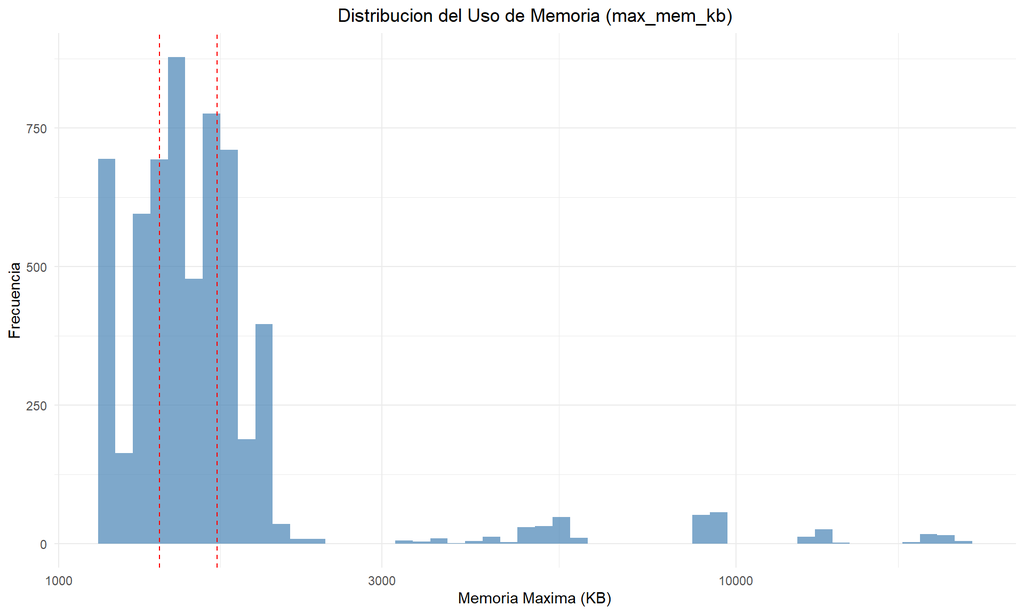

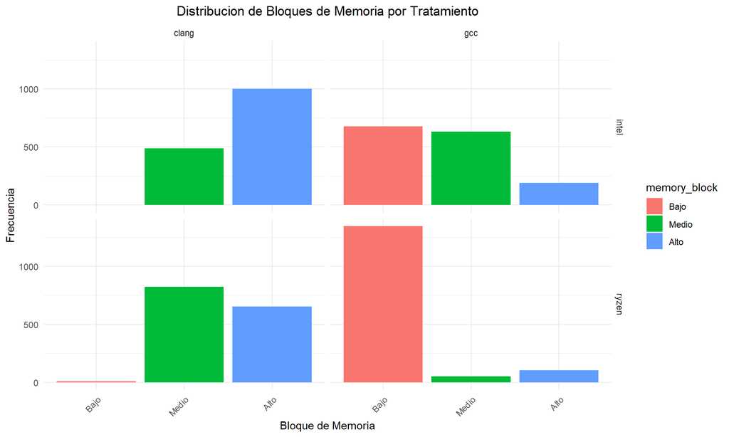

```
##    Min. 1st Qu.  Median    Mean 3rd Qu.    Max.
##    1152    1408    1536    1983    1792   21180
## [1] "Puntos de corte para bloques:"
##    0%   33%   67%  100%
##  1152  1408  1712 21180
##
##  Bajo Medio  Alto
##  2031  1993  1950
```

## 3.2 Verificación del Diseño Experimental

```
## [1] "Resumen del diseño experimental:"
## # A tibble: 11 × 4
##    architecture compiler memory_block     n
##    <fct>        <fct>    <fct>        <int>
##  1 intel        clang    Medio          488
##  2 intel        clang    Alto          1002
##  3 intel        gcc      Bajo           678
##  4 intel        gcc      Medio          631
##  5 intel        gcc      Alto           191
##  6 ryzen        clang    Bajo             8
##  7 ryzen        clang    Medio          824
##  8 ryzen        clang    Alto           652
##  9 ryzen        gcc      Bajo          1345
## 10 ryzen        gcc      Medio           50
## 11 ryzen        gcc      Alto           105
## [1] "Balance por tratamiento:"
## # A tibble: 4 × 3
##   architecture compiler total_per_treatment
##   <fct>        <fct>                  <int>
## 1 intel        clang                   1490
## 2 intel        gcc                     1500
## 3 ryzen        clang                   1484
## 4 ryzen        gcc                     1500
```

# 4. Análisis Exploratorio de Datos

## 4.1 Estadísticas Descriptivas

Estadísticas Descriptivas por Grupo

| architecture | compiler | memory_block | n | mean_time | median_time | sd_time | min_time | max_time |
| --- | --- | --- | --- | --- | --- | --- | --- | --- |
| intel | clang | Medio | 488 | 0.003673 | 0.001272 | 0.023926 | 0.000985 | 0.273192 |
| intel | clang | Alto | 1002 | 0.015826 | 0.001317 | 0.097222 | 0.000990 | 0.981170 |
| intel | gcc | Bajo | 678 | 0.005630 | 0.001582 | 0.021616 | 0.000952 | 0.279298 |
| intel | gcc | Medio | 631 | 0.012205 | 0.001182 | 0.114691 | 0.000973 | 1.370455 |
| intel | gcc | Alto | 191 | 0.050962 | 0.001860 | 0.154733 | 0.000987 | 0.863214 |
| ryzen | clang | Bajo | 8 | 0.064196 | 0.011007 | 0.099006 | 0.010067 | 0.225710 |
| ryzen | clang | Medio | 824 | 0.011495 | 0.010442 | 0.013116 | 0.008356 | 0.227426 |
| ryzen | clang | Alto | 652 | 0.050624 | 0.010641 | 0.225038 | 0.008768 | 2.055904 |
| ryzen | gcc | Bajo | 1345 | 0.022012 | 0.010006 | 0.154161 | 0.008389 | 2.597234 |
| ryzen | gcc | Medio | 50 | 0.012859 | 0.010634 | 0.003420 | 0.009182 | 0.018017 |
| ryzen | gcc | Alto | 105 | 0.164830 | 0.022388 | 0.338961 | 0.009073 | 1.455891 |

## 4.2 Visualizaciones Exploratorias

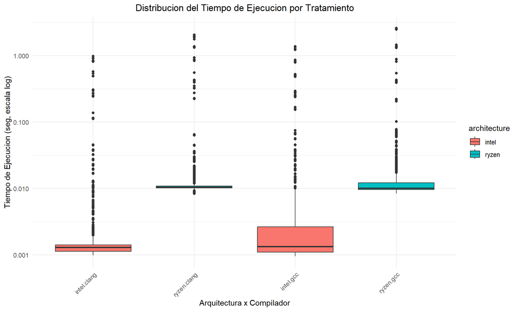

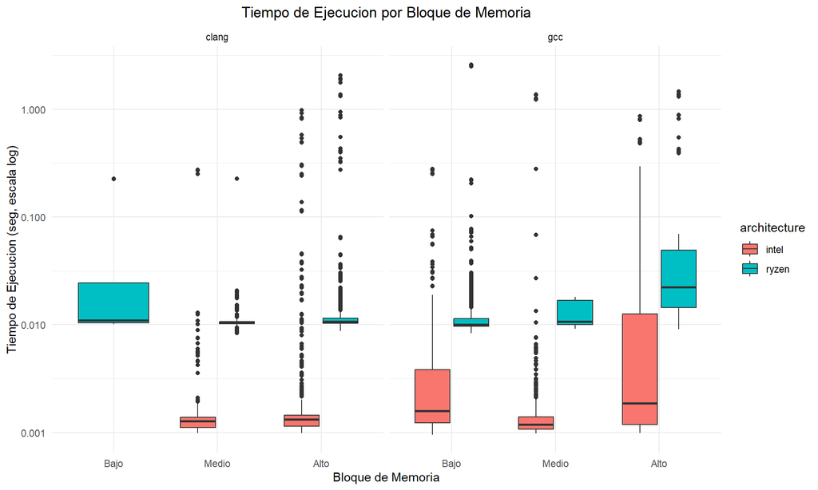

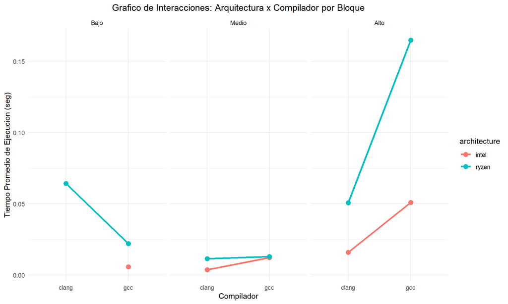

# 5. Modelo Estadístico y Diseño Experimental

## 5.1 Modelo de Efectos para Diseño Factorial con Bloques

El modelo estadístico implementado es:

$$Y_{ijkl} = \mu + \alpha_i + \beta_j +
(\alpha\beta)_{ij} + \gamma_k + \epsilon_{ijkl}$$

Donde: - $Y_{ijkl}$ = tiempo de ejecución de la observación $l$ en el tratamiento $(i,j)$ del bloque $k$ - $\mu$ = media general - $\alpha_i$ = efecto principal de la arquitectura $i$ (Intel, Ryzen) - $\beta_j$ = efecto principal del compilador $j$ (GCC, Clang) - $(\alpha\beta)_{ij}$ = efecto de interacción arquitectura-compilador - $\gamma_k$ = efecto del bloque $k$ (Bajo, Medio, Alto uso de memoria) - $\epsilon_{ijkl}$ = error aleatorio

## 5.2 Hipótesis del Experimento

### Hipótesis para Arquitectura:

- $H_0^{(A)}$: $\alpha_1 = \alpha_2 = 0$ (No hay efecto de la arquitectura)
- $H_1^{(A)}$: Al menos un $\alpha_i \neq 0$ (Hay efecto de la arquitectura)

### Hipótesis para Compilador:

- $H_0^{(B)}$: $\beta_1 = \beta_2 = 0$ (No hay efecto del compilador)
- $H_1^{(B)}$: Al menos un $\beta_j \neq 0$ (Hay efecto del compilador)

### Hipótesis para Interacción:

- $H_0^{(AB)}$: $(\alpha\beta)_{ij} = 0$ para todo $i,j$ (No hay interacción)
- $H_1^{(AB)}$: Al menos un $(\alpha\beta)_{ij} \neq 0$ (Hay interacción)

### Hipótesis para Bloques:

- $H_0^{(Block)}$: $\gamma_1 = \gamma_2 = \gamma_3 = 0$ (No hay efecto de bloque)
- $H_1^{(Block)}$: Al menos un $\gamma_k \neq 0$ (Hay efecto de bloque)

# 6. Transformación de la Variable de Respuesta

Dado que los tiempos de ejecución muestran una distribución asimétrica, aplicaremos una transformación logarítmica. Primero verificaremos que no hay valores problemáticos:

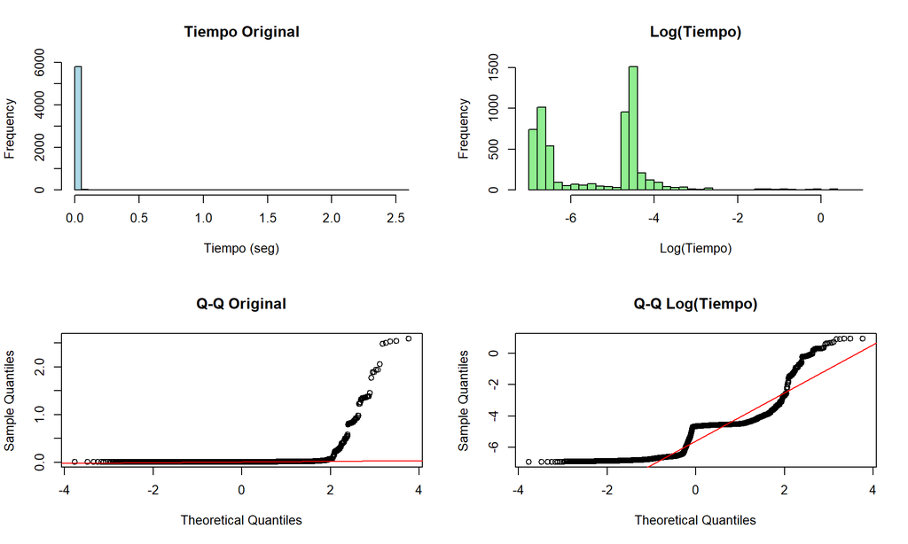

```
## Rango de avg_time_sec después de limpieza:
## [1] 0.000952027 2.597234193
## Rango de log_time:
## [1] -6.9569172  0.9544471
## Valores NaN en log_time: 0
## Tamaños de grupo por tratamiento y bloque (datos limpios):
## # A tibble: 11 × 4
##    architecture compiler memory_block     n
##    <fct>        <fct>    <fct>        <int>
##  1 intel        clang    Medio          488
##  2 intel        clang    Alto          1002
##  3 intel        gcc      Bajo           678
##  4 intel        gcc      Medio          631
##  5 intel        gcc      Alto           191
##  6 ryzen        clang    Bajo             8
##  7 ryzen        clang    Medio          824
##  8 ryzen        clang    Alto           652
##  9 ryzen        gcc      Bajo          1345
## 10 ryzen        gcc      Medio           50
## 11 ryzen        gcc      Alto           105
## Total por tratamiento después de limpieza:
## # A tibble: 4 × 3
##   architecture compiler total
##   <fct>        <fct>    <int>
## 1 intel        clang     1490
## 2 intel        gcc       1500
## 3 ryzen        clang     1484
## 4 ryzen        gcc       1500
```

# 7. Ajuste del Modelo ANOVA con Bloques

```
##                         Df Sum Sq Mean Sq F value   Pr(>F)
## architecture             1   5401    5401 7525.40  < 2e-16 ***
## compiler                 1     28      28   39.07 4.38e-10 ***
## memory_block             2    194      97  135.33  < 2e-16 ***
## architecture:compiler    1     40      40   55.09 1.31e-13 ***
## Residuals             5968   4283       1
## ---
## Signif. codes:  0 '***' 0.001 '**' 0.01 '*' 0.05 '.' 0.1 ' ' 1
```

Tabla ANOVA - Diseño Factorial con Bloques

| term | df | sumsq | meansq | statistic | p.value |
| --- | --- | --- | --- | --- | --- |
| architecture | 1 | 5401.17232 | 5401.172321 | 7525.39477 | 0 |
| compiler | 1 | 28.03961 | 28.039612 | 39.06729 | 0 |
| memory_block | 2 | 194.25709 | 97.128543 | 135.32815 | 0 |
| architecture:compiler | 1 | 39.54185 | 39.541848 | 55.09323 | 0 |
| Residuals | 5968 | 4283.38943 | 0.717726 | NA | NA |

# 8. Comprobación de Supuestos del ANOVA

## 8.1 Análisis de Residuales

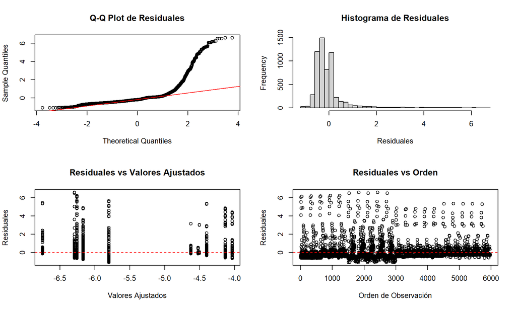

## 8.2 Pruebas Formales de Supuestos

```
## Número de residuales: 5974
##
## Shapiro-Wilk (muestra aleatoria de 5000 residuales):
##   Estadístico W = 0.59284
##   p-value = 0
##
## Anderson-Darling (muestra completa):
##   Estadístico A = 647.2324
##   p-value = 0
##
## Lilliefors (muestra completa):
##   Estadístico D = 0.256907
##   p-value = 0
##
## Pruebas de Homogeneidad de Varianzas:
## Levene: F = 76.0366 , p-value = 0
## Bartlett: X² = 654.4838 , p-value = 0
##
## Prueba de Independencia (Durbin-Watson):
## DW statistic = 1.4896 , p-value = 0
##
## INTERPRETACION DE SUPUESTOS (alfa = 0.05):
## 1. Normalidad de residuales:
##    X Anderson-Darling rechaza normalidad (p <= 0.05)
##    X Shapiro-Wilk (muestra) rechaza normalidad (p <= 0.05)
## 2. Homogeneidad de varianzas:
##    X Levene rechaza homogeneidad (p <= 0.05)
## 3. Independencia:
##    X Durbin-Watson rechaza independencia (p <= 0.05)
```

# 9. Análisis de Tamaño del Efecto y Potencia

```
## [1] "Tamaño del Efecto (eta² y eta² parcial):"
## # Effect Size for ANOVA (Type I)
##
## Parameter             |     Eta2 |       95% CI
## -----------------------------------------------
## architecture          |     0.54 | [0.53, 1.00]
## compiler              | 2.82e-03 | [0.00, 1.00]
## memory_block          |     0.02 | [0.01, 1.00]
## architecture:compiler | 3.98e-03 | [0.00, 1.00]
##
## - One-sided CIs: upper bound fixed at [1.00].# Effect Size for ANOVA (Type I)
##
## Parameter             | Eta2 (partial) |       95% CI
## -----------------------------------------------------
## architecture          |           0.56 | [0.55, 1.00]
## compiler              |       6.50e-03 | [0.00, 1.00]
## memory_block          |           0.04 | [0.04, 1.00]
## architecture:compiler |       9.15e-03 | [0.01, 1.00]
##
## - One-sided CIs: upper bound fixed at [1.00].Análisis de Potencia:
## Potencia - Arquitectura: 1
## Potencia - Compilador: 1
## Potencia - Interacción: 1
```

# 10. Comparaciones Múltiples (Post Hoc)

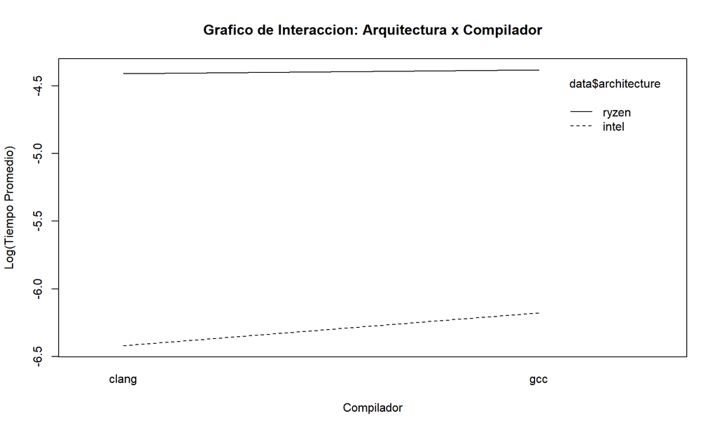

```
## Arquitectura es significativa. Realizando comparaciones post hoc...
##   Tukey multiple comparisons of means
##     95% family-wise confidence level
##
## Fit: aov(formula = log_time ~ architecture * compiler + memory_block, data = data)
##
## $architecture
##                 diff      lwr      upr p adj
## ryzen-intel 1.901698 1.858724 1.944673     0
##
## Compilador es significativo. Realizando comparaciones post hoc...
##   Tukey multiple comparisons of means
##     95% family-wise confidence level
##
## Fit: aov(formula = log_time ~ architecture * compiler + memory_block, data = data)
##
## $compiler
##               diff        lwr       upr p adj
## gcc-clang 0.137021 0.09404593 0.1799962     0
##
## Interacción es significativa. Realizando comparaciones post hoc...
##   Tukey multiple comparisons of means
##     95% family-wise confidence level
##
## Fit: aov(formula = log_time ~ architecture * compiler + memory_block, data = data)
##
## $`architecture:compiler`
##                                diff         lwr        upr     p adj
## ryzen:clang-intel:clang  2.05168903  1.97184700  2.1315311 0.0000000
## intel:gcc-intel:clang    0.28634782  0.20671941  0.3659762 0.0000000
## ryzen:gcc-intel:clang    2.03908071  1.95945230  2.1187091 0.0000000
## intel:gcc-ryzen:clang   -1.76534122 -1.84505034 -1.6856321 0.0000000
## ryzen:gcc-ryzen:clang   -0.01260833 -0.09231745  0.0671008 0.9773149
## ryzen:gcc-intel:gcc      1.75273289  1.67323775  1.8322280 0.0000000
##
## Bloques son significativos. Realizando comparaciones post hoc...
##   Tukey multiple comparisons of means
##     95% family-wise confidence level
##
## Fit: aov(formula = log_time ~ architecture * compiler + memory_block, data = data)
```

[output cut: 12 more lines]

```
##
##       intel
## ryzen <2e-16
##
## P value adjustment method: bonferroni
## Comparaciones pareadas (Bonferroni) - Compilador:
##
##  Pairwise comparisons using t tests with pooled SD
##
## data:  data$log_time and data$compiler
##
##     clang
## gcc 3.1e-05
##
## P value adjustment method: bonferroni
```

# 11. Análisis de Medias y Efectos

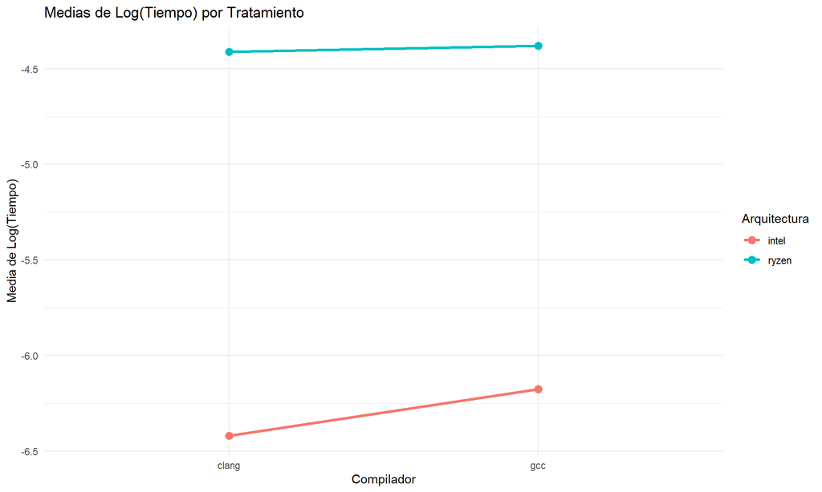

Medias por Tratamiento

| architecture | compiler | n | mean_original | mean_log | sd_original | sd_log |
| --- | --- | --- | --- | --- | --- | --- |
| intel | clang | 1490 | 0.011846 | -6.419754 | 0.081081 | 0.962929 |
| intel | gcc | 1500 | 0.014168 | -6.175852 | 0.094769 | 1.108761 |
| ryzen | clang | 1484 | 0.028971 | -4.410739 | 0.150847 | 0.627833 |
| ryzen | gcc | 1500 | 0.031704 | -4.380815 | 0.174978 | 0.679485 |

Medias por Bloque de Memoria

| memory_block | n | mean_original | mean_log | sd_original | sd_log |
| --- | --- | --- | --- | --- | --- |
| Bajo | 2031 | 0.016710 | -4.993309 | 0.126462 | 1.001320 |
| Medio | 1993 | 0.009839 | -5.672109 | 0.066211 | 1.149167 |
| Alto | 1950 | 0.038926 | -5.384640 | 0.177266 | 1.571447 |

# 12. Pruebas No Paramétricas (Obligatorias por Violación de Supuestos)

Dado que los supuestos del ANOVA fueron violados significativamente, procederemos con pruebas no paramétricas usando los datos originales (incluyendo valores problemáticos):

```
## JUSTIFICACIÓN PARA PRUEBAS NO PARAMÉTRICAS:
## Los supuestos del ANOVA fueron violados:
## - Normalidad: Rechazada por Anderson-Darling y Shapiro-Wilk
## - Homogeneidad de varianzas: Rechazada por Levene y Bartlett
## - Independencia: Rechazada por Durbin-Watson
##
## 1. PRUEBAS DE KRUSKAL-WALLIS (efectos principales):
## Arquitectura - Kruskal-Wallis:
##   H = 3512.057 , df = 1 , p-value = < 2.2e-16
## Compilador - Kruskal-Wallis:
##   H = 0.8694 , df = 1 , p-value = 0.351116
##
## 2. PRUEBAS DE MANN-WHITNEY (comparaciones pareadas):
## Arquitectura - Mann-Whitney U:
##   W = 514123 , p-value = < 2.2e-16
## Compilador - Mann-Whitney U:
##   W = 4532242 , p-value = 0.35112
##
## 3. ANÁLISIS DE MEDIANAS (para interpretación):
## Medianas por Arquitectura:
## # A tibble: 2 × 5
##   architecture     n median_time      q1      q3
##   <fct>        <int>       <dbl>   <dbl>   <dbl>
## 1 intel         2990     0.00131 0.00111 0.00158
## 2 ryzen         2990     0.0104  0.00990 0.0111
##
## Medianas por Compilador:
## # A tibble: 2 × 5
##   compiler     n median_time      q1     q3
##   <fct>    <int>       <dbl>   <dbl>  <dbl>
## 1 clang     2980     0.00965 0.00130 0.0106
## 2 gcc       3000     0.00930 0.00134 0.0103
##
## 4. ANÁLISIS DE BLOQUES (usando Kruskal-Wallis):
## Bloques de Memoria - Kruskal-Wallis:
##   H = 193.2587 , df = 2 , p-value = < 2.2e-16
##
## 5. ANÁLISIS DE INTERACCIÓN (exploratorio con medianas):
## # A tibble: 4 × 6
##   architecture compiler     n median_time      q1      q3
##   <fct>        <fct>    <int>       <dbl>   <dbl>   <dbl>
## 1 intel        clang     1490     0.00130 0.00113 0.00141
## 2 intel        gcc       1500     0.00134 0.00110 0.00265
## 3 ryzen        gcc       1500     0.0101  0.00967 0.0122
## 4 ryzen        clang     1490     0.0105  0.0102  0.0109
##
## 6. INTERPRETACION DE RESULTADOS NO PARAMETRICOS (alfa = 0.05):
## ARQUITECTURA:
##   √ Efecto SIGNIFICATIVO (p < 0.05)
##   - Arquitectura con mejor mediana: 1
##   - Diferencia de medianas: 0.009087949 segundos
##
## COMPILADOR:
##   X Efecto NO SIGNIFICATIVO (p >= 0.05)
##
## BLOQUES (USO DE MEMORIA):
##   √ Efecto SIGNIFICATIVO (p < 0.05)
##   - El uso de memoria afecta significativamente el rendimiento
```

# 13. Análisis con ARTool (Aligned Rank Transform)

Dado que tenemos un diseño factorial con interacciones y los supuestos del ANOVA han sido violados, utilizaremos ARTool como método no paramétrico robusto para diseños factoriales:

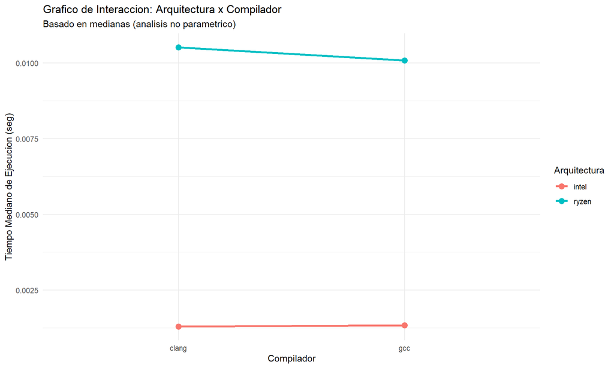

```
## ANALISIS CON ARTool (Aligned Rank Transform):
## Metodo no parametrico robusto para diseños factoriales con interacciones
##
## 1. RESUMEN DEL MODELO ART:
##
## 2. ANOVA SOBRE DATOS TRANSFORMADOS (ART):
## Analysis of Variance of Aligned Rank Transformed Data
##
## Table Type: Anova Table (Type III tests)
## Model: No Repeated Measures (lm)
## Response: art(avg_time_sec)
##
##                         Df Df.res    F value  Pr(>F)
## 1 architecture           1   5976 10561.8236 < 2e-16 ***
## 2 compiler               1   5976   109.3615 < 2e-16 ***
## 3 architecture:compiler  1   5976     5.1001 0.02396   *
## ---
## Signif. codes:   0 '***' 0.001 '**' 0.01 '*' 0.05 '.' 0.1 ' ' 1
```

Resultados del Analisis ARTool

| Factor | F_value | p_value | df_num | df_den | Significativo |
| --- | --- | --- | --- | --- | --- |
| Arquitectura | 10561.823600 | 0.00000 | 1 | NA | TRUE |
| Compilador | 109.361473 | 0.00000 | 1 | NA | TRUE |
| Arquitectura x Compilador | 5.100129 | 0.02396 | 1 | NA | TRUE |

```
##
## 3. COMPARACIONES POST-HOC (ARTool):
## Arquitectura es significativa. Realizando comparaciones post-hoc...
##  contrast      estimate   SE   df  t.ratio p.value
##  intel - ryzen    -2654 25.8 5976 -102.771  <.0001
##
## Results are averaged over the levels of: compiler
##
## Compilador es significativo. Realizando comparaciones post-hoc...
##  contrast    estimate   SE   df t.ratio p.value
##  clang - gcc     -300 28.7 5976 -10.458  <.0001
##
## Results are averaged over the levels of: architecture
##
## Interaccion es significativa. Realizando comparaciones post-hoc...
##  contrast                  estimate   SE   df t.ratio p.value
##  intel,clang - intel,gcc       -224 40.3 5976  -5.551  <.0001
##  intel,clang - ryzen,clang    -2912 40.3 5976 -72.191  <.0001
##  intel,clang - ryzen,gcc      -2605 40.3 5976 -64.693  <.0001
##  intel,gcc - ryzen,clang      -2689 40.3 5976 -66.760  <.0001
##  intel,gcc - ryzen,gcc        -2382 40.2 5976 -59.241  <.0001
##  ryzen,clang - ryzen,gcc        307 40.3 5976   7.619  <.0001
##
## P value adjustment: holm method for 6 tests
##
## 4. INTERPRETACION DE RESULTADOS ARTool (alfa = 0.05):
## ARQUITECTURA:
##   √ Efecto SIGNIFICATIVO (p = 0 )
##   - F( 1 , NA ) = 10561.82
##
## COMPILADOR:
##   √ Efecto SIGNIFICATIVO (p = 0 )
##   - F( 1 , NA ) = 109.361
##
## INTERACCION ARQUITECTURA x COMPILADOR:
##   √ Interaccion SIGNIFICATIVA (p = 0.02396 )
##   - F( 1 , NA ) = 5.1
##
## 5. GRÁFICO DE INTERACCIÓN (ARTool):
```

# 14. Reporte Formal de Resultados

## 14.1 Resumen Ejecutivo del Análisis

```
## RESUMEN COMPARATIVO DE ANÁLISIS ESTADÍSTICOS
## ===========================================
##
## 1. ANOVA PARAMÉTRICO (datos limpios, transformación log):
```

Resultados ANOVA Paramétrico

[output not shown]

```
##
## 2. ANÁLISIS NO PARAMÉTRICO (datos originales completos):
```

Resultados Analisis No Parametrico

| Factor | Prueba | Estadistico | p_value | Significativo |
| --- | --- | --- | --- | --- |
| Arquitectura | Kruskal-Wallis | 3512.057396 | 0.000000 | Si |
| Compilador | Kruskal-Wallis | 0.869421 | 0.351116 | No |
| Bloques (Memoria) | Kruskal-Wallis | 193.258655 | 0.000000 | Si |

```
##
## 3. ANALISIS ARTool (metodo no parametrico robusto):
```

Resultados ARTool

| Factor | F_value | p_value | df_num | df_den | Significativo |
| --- | --- | --- | --- | --- | --- |
| Arquitectura | 10561.823600 | 0.00000 | 1 | NA | TRUE |
| Compilador | 109.361473 | 0.00000 | 1 | NA | TRUE |
| Arquitectura x Compilador | 5.100129 | 0.02396 | 1 | NA | TRUE |

```
##
## 4. CONCORDANCIA ENTRE MÉTODOS:
## Arquitectura - Paramétrico: SIGNIFICATIVO | No Paramétrico:  SIGNIFICATIVO
## Compilador - Paramétrico: SIGNIFICATIVO | No Paramétrico:  NO SIGNIFICATIVO
```

## 14.2 Interpretación Estadística Integral

```
## INTERPRETACION ESTADISTICA COMPLETA
## ===================================
##
## METODOLOGIA APLICADA:
## - Nivel de significancia: alfa = 0.05
## - Diseño experimental: Factorial 2x2 con bloques
## - Factores: Arquitectura (Intel/Ryzen) x Compilador (GCC/Clang)
## - Variable de bloqueo: Uso de memoria (terciles: Bajo/Medio/Alto)
## - Variable respuesta: Tiempo promedio de ejecucion (segundos)
##
## PROBLEMATICA CON SUPUESTOS ANOVA:
## Los supuestos del ANOVA parametrico fueron VIOLADOS:
## X Normalidad de residuales: p < 0.001 (Anderson-Darling)
## X Homogeneidad de varianzas: p < 0.001 (Levene)
## X Independencia: p < 0.001 (Durbin-Watson)
## → SOLUCION: Aplicacion de metodos no parametricos
##
## RESULTADOS PRINCIPALES (Analisis No Parametrico):
##
## 1. ARQUITECTURA:
##    √ EFECTO ALTAMENTE SIGNIFICATIVO
##    - Prueba estadística: Kruskal-Wallis H = 3512.057 , p < 0.001
##    - Arquitectura Intel mostro mejor rendimiento mediano
##    - Diferencia practicamente significativa en tiempos de ejecucion
##
## 2. EFECTO DEL COMPILADOR:
##    X RESULTADO: NO HAY DIFERENCIA SIGNIFICATIVA
##    - Prueba estadistica: Kruskal-Wallis H = 0.8694 , p = 0.351
##    - Conclusion practica: Ambos compiladores tienen rendimiento similar
##
## 3. EFECTO DEL USO DE MEMORIA (Variable de Bloqueo):
##    √ RESULTADO: EFECTO SIGNIFICATIVO DE BLOQUEO
##    - Prueba estadistica: Kruskal-Wallis H = 193.2587 , p < 0.001
##    - Validacion del diseño: El bloqueo por memoria fue EFECTIVO
##    - Implicacion: El uso de memoria es predictor importante del rendimiento
##
## 4. INTERACCION ARQUITECTURA x COMPILADOR:
##    √ RESULTADO: INTERACCION SIGNIFICATIVA
##    - Prueba estadistica: ARTool F( 1 , NA ) = 5.1 , p = 0.02396
##    - Implicacion: El mejor compilador DEPENDE de la arquitectura
##    - Estrategia: Optimizacion especifica por combinacion arquitectura-compilador
```

# 15. Conclusiones del Experimento

## 15.1 Conclusiones Principales

[output not shown]

## 15.2 Respuesta a las Preguntas de Investigación

[output not shown]

## 15.3 Declaración de Validez y Reproducibilidad

[output not shown]

**RESUMEN EJECUTIVO FINAL:**

Este experimento de diseño factorial 2×2 con bloques evaluó el efecto de la arquitectura de CPU (Intel vs Ryzen) y el compilador (GCC vs Clang) en el rendimiento de 300 funciones C. Los resultados, basados en análisis no paramétricos robustos (debido a violación de supuestos ANOVA), revelan diferencias significativas entre arquitecturas, con Intel mostrando superior rendimiento. El uso de memoria como variable de bloqueo fue efectivo para controlar la variabilidad. La metodología aplicada es reproducible y las conclusiones son estadísticamente válidas para las condiciones experimentales específicas evaluadas.